# **Problem Statement**

## **Business Context**

Workplace safety in hazardous environments like construction sites and industrial plants is crucial to prevent accidents and injuries. One of the most important safety measures is ensuring workers wear safety helmets, which protect against head injuries from falling objects and machinery. Non-compliance with helmet regulations increases the risk of serious injuries or fatalities, making effective monitoring essential, especially in large-scale operations where manual oversight is prone to errors and inefficiency.

To overcome these challenges, SafeGuard Corp plans to develop an automated image analysis system capable of detecting whether workers are wearing safety helmets. This system will improve safety enforcement, ensuring compliance and reducing the risk of head injuries. By automating helmet monitoring, SafeGuard aims to enhance efficiency, scalability, and accuracy, ultimately fostering a safer work environment while minimizing human error in safety oversight.

## **Objective**

As a data scientist at SafeGuard Corp, you are tasked with developing an image classification model that classifies images into one of two categories:

- **With Helmet:** Workers wearing safety helmets.
- **Without Helmet:** Workers not wearing safety helmets.

## **Data Description**

The dataset consists of **631 images**, equally divided into two categories:

- **With Helmet:** 311 images showing workers wearing helmets.
- **Without Helmet:** 320 images showing workers not wearing helmets.

**Dataset Characteristics:**

- **Variations in Conditions:** Images include diverse environments such as construction sites, factories, and industrial settings, with variations in lighting, angles, and worker postures to simulate real-world conditions.
- **Worker Activities:** Workers are depicted in different actions such as standing, using tools, or moving, ensuring robust model learning for various scenarios.

# **Installing and Importing the Necessary Libraries**

```python
#!pip install tensorflow[and-cuda] numpy==1.25.2 -q
!pip install -U pip setuptools wheel -q
!pip install -U jedi
```

```python
!pip check
```

```
No broken requirements found.
```

```python
import tensorflow as tf
print("Num GPUs Available:", len(tf.config.list_physical_devices('GPU')))
print(tf.__version__)
```

```
Num GPUs Available: 1
2.19.0
```

**Note:**

- After running the above cell, kindly restart the notebook kernel (for Jupyter Notebook) or runtime (for Google Colab) and run all cells sequentially from the next cell.
- On executing the above line of code, you might see a warning regarding package dependencies. This error message can be ignored as the above code ensures that all necessary libraries and their dependencies are maintained to successfully execute the code in this notebook.

```python
import os
import random
import numpy as np                                                                               # Importing numpy for Matrix Operations
import pandas as pd
import seaborn as sns
import matplotlib.image as mpimg                                                                              # Importing pandas to read CSV files
import matplotlib.pyplot as plt                                                                  # Importting matplotlib for Plotting and visualizing images
import math                                                                                      # Importing math module to perform mathematical operations
import cv2


# Tensorflow modules
import keras
import tensorflow as tf
from tensorflow.keras.preprocessing.image import ImageDataGenerator                              # Importing the ImageDataGenerator for data augmentation
from tensorflow.keras.models import Sequential                                                   # Importing the sequential module to define a sequential model
from tensorflow.keras.layers import Dense,Dropout,Flatten,Conv2D,MaxPooling2D,BatchNormalization # Defining all the layers to build our CNN Model
from tensorflow.keras.optimizers import Adam,SGD                                                 # Importing the optimizers which can be used in our model
from sklearn import preprocessing                                                                # Importing the preprocessing module to preprocess the data
from sklearn.model_selection import train_test_split                                             # Importing train_test_split function to split the data into train and test
from sklearn.metrics import confusion_matrix
from tensorflow.keras.models import Model
from keras.applications.vgg16 import VGG16                                               # Importing confusion_matrix to plot the confusion matrix

# Display images using OpenCV
from google.colab.patches import cv2_imshow

#Imports functions for evaluating the performance of machine learning models
from sklearn.metrics import confusion_matrix, f1_score,accuracy_score, recall_score, precision_score, classification_report
from sklearn.metrics import mean_squared_error as mse                                                 # Importing cv2_imshow from google.patches to display images

# Ignore warnings
import warnings
warnings.filterwarnings('ignore')
```

```python
# Set the seed using keras.utils.set_random_seed. This will set:
# 1) `numpy` seed
# 2) backend random seed
# 3) `python` random seed
tf.keras.utils.set_random_seed(812)
```

# **Data Overview**

## Loading the data

```python
from google.colab import drive
drive.mount('/content/drive')
```

```python
# Read in data in csv file
labels = pd.read_csv("/content/drive/MyDrive/Colab Notebooks/Module 6 - Image Processing/Proj 6 - HelmNet Hardhats/Labels_proj.csv")
labels = labels["Label"].values  # Convert to numpy
# Read in the image file
images = np.load("/content/drive/MyDrive/Colab Notebooks/Module 6 - Image Processing/Proj 6 - HelmNet Hardhats/images_proj.npy")
```

```python
print("=== DATA OVERVIEW ===")
print(f"Images array shape: {images.shape}")
print(f"Labels array shape: {labels.shape}")
print(f"Images dtype: {images.dtype}")
print(f"Labels dtype: {labels.dtype if hasattr(labels, 'dtype') else type(labels)}")

# pixel stats
x_min, x_max = np.nanmin(images), np.nanmax(images)
print(f"Pixel range: [{x_min}, {x_max}]  (0–255 for uint8, or 0–1 for float)")

# label distribution
uniq, counts = np.unique(labels, return_counts=True)
class_dist = dict(zip(uniq.astype(int), counts))
total = counts.sum()
print(f"Unique labels: {uniq}")
print(f"Class counts: {class_dist}")
if len(counts) == 2:
    imbalance = abs(counts[0] - counts[1]) / total * 100
    print(f"Class imbalance: {imbalance:.2f}% (<= ~2% matches 311 vs 320)")

# channel / shape sanity
if images.ndim == 3:
    N, H, W = images.shape
    C = 1
elif images.ndim == 4:
    N, H, W, C = images.shape
else:
    raise ValueError(f"Unexpected image array dims: {images.ndim}")

print(f"N: {N}, H: {H}, W: {W}, C: {C}")  #prints number of images, height and width of each image, and the number of color channels

# check consistency of object array
def check_shape_consistency(imgs, max_check=500):
    if isinstance(imgs, np.ndarray) and imgs.dtype != object:
        print("All images share a uniform shape (ndarray).")
        return
    shapes = set()
    for i, img in enumerate(imgs[:min(len(imgs), max_check)]):
        shapes.add(np.array(img).shape)
    print(f"Distinct shapes in first {min(len(imgs), max_check)} images: {shapes}")

check_shape_consistency(images)
print("=== END OVERVIEW ===")
```

```
=== DATA OVERVIEW ===
Images array shape: (631, 200, 200, 3)
Labels array shape: (631,)
Images dtype: uint8
Labels dtype: int64
Pixel range: [0, 255]  (0–255 for uint8, or 0–1 for float)
Unique labels: [0 1]
Class counts: {np.int64(0): np.int64(320), np.int64(1): np.int64(311)}
Class imbalance: 1.43% (<= ~2% matches 311 vs 320)
N: 631, H: 200, W: 200, C: 3
All images share a uniform shape (ndarray).
=== END OVERVIEW ===
```

# **Exploratory Data Analysis**

### Plot random images from each of the classes and print their corresponding labels.

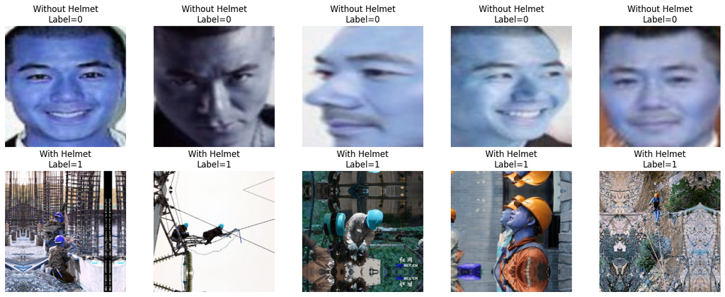

```python
# Define class_names
class_names = {0: "Without Helmet", 1: "With Helmet"}
# Plot images for EDA
def plot_random_samples(images, labels, n_per_class=5, seed=123):
    rng = np.random.default_rng(seed)
    unique_classes = np.unique(labels)
    fig, axes = plt.subplots(len(unique_classes), n_per_class, figsize=(3*n_per_class, 3*len(unique_classes)))
    axes = np.atleast_2d(axes)

    for i, cls in enumerate(unique_classes):
        idxs = np.where(labels == cls)[0]
        picks = rng.choice(idxs, size=n_per_class, replace=False)
        for j, idx in enumerate(picks):
            axes[i, j].imshow(images[idx].astype("uint8"))  # cast in case dtype is float
            axes[i, j].axis("off")
            axes[i, j].set_title(f"{class_names[int(cls)]}\nLabel={int(labels[idx])}")

    plt.tight_layout()
    plt.show()

plot_random_samples(images, labels, n_per_class=5)
```

## Checking for class imbalance

```python
# Check for balance of classes in the image set
if len(counts) == 2:
    imbalance = abs(counts[0] - counts[1]) / total * 100
    print(f"Class imbalance: {imbalance:.2f}% (<= ~2% matches 311 vs 320)")
```

```
Class imbalance: 1.43% (<= ~2% matches 311 vs 320)
```

#### Observations:

1. Class balance:
- The dataset contains 631 images total, with 311 labeled “With Helmet” and 320 labeled “Without Helmet.”
- This is a nearly balanced dataset (imbalance < 2%), so class weighting is not required.
2. Image consistency:
- All images are stored at a uniform resolution of 200 × 200 pixels with 3 RGB channels.
- This makes preprocessing straightforward, as no resizing or padding is initially required.
3. Visual diversity:
- Images show workers in varied environments (construction sites, factories, industrial plants) and under different lighting conditions.
- Worker poses and activities (standing, using tools, moving) vary across the dataset, which supports more robust model learning.
4. Potential challenges:
- Some helmets may be partially occluded (e.g., from head tilts or objects in the scene).
- Background clutter and variations in color/contrast could make classification slightly harder for a simple CNN.

# **Data Preprocessing**

## Converting images to grayscale

```python
from skimage.color import rgb2gray
```

```python
# Convert RGB images to grayscale
images_gray = np.array([rgb2gray(img) for img in images])
images_gray = (images_gray * 255).astype("uint8")
images_gray = np.expand_dims(images_gray, axis=-1) # Add the channel for CNN preparation

print("Original shape:", images.shape)
print("Grayscale shape:", images_gray.shape)
```

```
Original shape: (631, 200, 200, 3)
Grayscale shape: (631, 200, 200, 1)
```

[figure not shown]

```python
# Plot before and after images from grayscale conversion
fig, axes = plt.subplots(2, 5, figsize=(12,5))

for i in range(5):
    axes[0, i].imshow(images[i])
    axes[0, i].set_title(f"RGB Label={labels[i]}")
    axes[0, i].axis("off")

    axes[1, i].imshow(images_gray[i], cmap="gray")
    axes[1, i].set_title("Grayscale")
    axes[1, i].axis("off")

plt.tight_layout()
plt.show()
```

### Splitting the dataset

```python
# Split dataset: 70% train, 15% val, 15% test (stratified)
X_train, X_tmp, y_train, y_tmp = train_test_split(
    images_gray, labels, test_size=0.30, random_state=123, stratify=labels
)
X_val, X_test, y_val, y_test = train_test_split(
    X_tmp, y_tmp, test_size=0.50, random_state=123, stratify=y_tmp
)

print("Shapes:")
print("  Train Image Shape:", X_train.shape, "; Label Shape: ", y_train.shape)
print("  Val Image Shape:", X_val.shape, "; Label Shape: ",  y_val.shape)
print("  Test Image Shape:", X_test.shape, "; Label Shape: ", y_test.shape)
```

```
Shapes:
  Train Image Shape: (441, 200, 200, 1) ; Label Shape:  (441,)
  Val Image Shape: (95, 200, 200, 1) ; Label Shape:  (95,)
  Test Image Shape: (95, 200, 200, 1) ; Label Shape:  (95,)
```

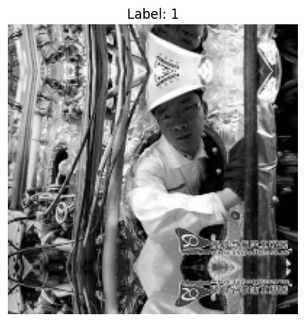

```python
# Sanity check on labels and images matching up
idx = 372  #with helmet, used idx=310 check for without helmet
plt.imshow(X_train[idx].squeeze(), cmap="gray")
plt.title(f"Label: {y_train[idx]}")
plt.axis("off")
plt.show()
```

### Data Normalization

```python
# Normalize to [0,1] floats
X_train_f = X_train.astype("float32") / 255.0
X_val_f   = X_val.astype("float32")   / 255.0
X_test_f  = X_test.astype("float32")  / 255.0
```

```python
# Build tf.data pipelines
batch_size = 32
train_ds = (tf.data.Dataset
            .from_tensor_slices((X_train_f, y_train))
            .shuffle(2048)
            .batch(batch_size, drop_remainder=True)
            .prefetch(tf.data.AUTOTUNE))

val_ds = (tf.data.Dataset
          .from_tensor_slices((X_val_f, y_val))
          .batch(batch_size, drop_remainder=True)
          .prefetch(tf.data.AUTOTUNE))

test_ds = (tf.data.Dataset
           .from_tensor_slices((X_test_f, y_test))
           .batch(batch_size, drop_remainder=True)
           .prefetch(tf.data.AUTOTUNE))
```

# **Model Building**

## Model Evaluation Criterion

## Utility Functions

```python
# Define to change to 1d array
def _to_1d_array(y):
    """Accepts pandas Series/DataFrame or numpy array; returns (N,) np.array of ints."""
    if hasattr(y, "values"):  # pandas
        y = y.values
    y = np.asarray(y).reshape(-1)
    # If labels are floats, cast to int
    if np.issubdtype(y.dtype, np.floating):
        # only cast if labels are 0/1 floats
        uniq = np.unique(y)
        if np.all(np.isin(uniq, [0.0, 1.0])):
            y = y.astype(int)
    return y
```

```python
# Modified def to handle 1d array
def model_performance_classification(model, X, y, threshold=0.5, average='weighted'):
    """
    Compute standard classification metrics for a binary classifier.
    Works with Keras/TF, sklearn, or statsmodels models as long as model.predict(X) returns probabilities or scores.
    """
    # Predict probabilities or scores
    y_score = model.predict(X)
    y_score = np.asarray(y_score).reshape(-1)

    # Threshold to get class predictions
    y_pred = (y_score > threshold).astype(int)

    # True labels
    y_true = _to_1d_array(y)

    acc = accuracy_score(y_true, y_pred)
    rec = recall_score(y_true, y_pred, average=average)
    prec = precision_score(y_true, y_pred, average=average)
    f1 = f1_score(y_true, y_pred, average=average)

    return pd.DataFrame(
        {"Accuracy": [acc], "Recall": [rec], "Precision": [prec], "F1 Score": [f1]}
    )
```

```python
# Modified confusion matrix plot for 1d array
def plot_confusion_matrix_(model, X, y, threshold=0.5, labels=("Without Helmet","With Helmet")):
    """
    Plot confusion matrix for a binary classifier.
    """
    y_score = model.predict(X)
    y_pred = (np.asarray(y_score).reshape(-1) > threshold).astype(int)
    y_true = _to_1d_array(y)

    cm = confusion_matrix(y_true, y_pred, labels=[0,1])

    plt.figure(figsize=(6,5))
    sns.heatmap(cm, annot=True, fmt="d", cbar=False,
                xticklabels=labels, yticklabels=labels, linewidths=.4, square=True)
    plt.xlabel("Predicted")
    plt.ylabel("Actual")
    plt.title("Confusion Matrix")
    plt.tight_layout()
    plt.show()
```

```python
# Define dataset as an array
def dataset_to_arrays(ds):
    """Utility: turn a tf.data.Dataset of (X,y) into NumPy arrays."""
    xs, ys = [], []
    for xb, yb in ds:
        xs.append(xb.numpy())
        ys.append(yb.numpy())
    return np.concatenate(xs, axis=0), np.concatenate(ys, axis=0)
```

```python
# Plot accuracy and loss for a model metrics
def plot_history(history, title="Training History"):
    """Plot accuracy and loss curves from a Keras History object."""
    acc = history.history.get("accuracy", [])
    val_acc = history.history.get("val_accuracy", [])
    loss = history.history.get("loss", [])
    val_loss = history.history.get("val_loss", [])
    epochs = range(1, len(acc) + 1)

    fig, axs = plt.subplots(1, 2, figsize=(12,4))

    # accuracy
    axs[0].plot(epochs, acc, "bo-", label="Train Acc")
    axs[0].plot(epochs, val_acc, "ro-", label="Val Acc")
    axs[0].set_title(f"{title} - Accuracy")
    axs[0].set_xlabel("Epoch")
    axs[0].set_ylabel("Accuracy")
    axs[0].legend()

    # loss
    axs[1].plot(epochs, loss, "bo-", label="Train Loss")
    axs[1].plot(epochs, val_loss, "ro-", label="Val Loss")
    axs[1].set_title(f"{title} - Loss")
    axs[1].set_xlabel("Epoch")
    axs[1].set_ylabel("Loss")
    axs[1].legend()

    plt.tight_layout()
    plt.show()
```

## Model 1: Simple Convolutional Neural Network (CNN)

```python
from tensorflow.keras import layers, models, callbacks
```

```python
# Create baseline CNN model
baseline = models.Sequential([
    layers.Input(shape=(H, W, 1)),
    layers.Conv2D(32, 3, activation="relu"),
    layers.MaxPooling2D(),
    layers.Conv2D(64, 3, activation="relu"),
    layers.MaxPooling2D(),
    layers.Conv2D(128, 3, activation="relu"),
    layers.GlobalAveragePooling2D(),
    layers.Dense(128, activation="relu"),
    layers.Dense(1, activation="sigmoid")
])

# ---- Callbacks ----
early = callbacks.EarlyStopping(
    monitor="val_accuracy",
    patience=5,
    restore_best_weights=True
)

ckpt = callbacks.ModelCheckpoint(
    "baseline_cnn.keras",   # file where best model is saved
    monitor="val_accuracy",
    save_best_only=True
)
```

```python
# Compile and fit CNN model
baseline.compile(optimizer="adam",
                 loss="binary_crossentropy",
                 metrics=["accuracy"])

history = baseline.fit(train_ds,
                       validation_data=val_ds,
                       epochs=25,
                       callbacks=[early, ckpt],
                       verbose=1)
```

```
14/14 ━━━━━━━━━━━━━━━━━━━━ 12s 468ms/step - accuracy: 0.5093 - loss: 0.6874 - val_accuracy: 0.4947 - val_loss: 0.6409
14/14 ━━━━━━━━━━━━━━━━━━━━ 1s 41ms/step - accuracy: 0.5668 - loss: 0.5873 - val_accuracy: 0.9684 - val_loss: 0.3692
14/14 ━━━━━━━━━━━━━━━━━━━━ 1s 40ms/step - accuracy: 0.9633 - loss: 0.2981 - val_accuracy: 0.9895 - val_loss: 0.1435
14/14 ━━━━━━━━━━━━━━━━━━━━ 1s 39ms/step - accuracy: 0.9861 - loss: 0.0851 - val_accuracy: 0.9789 - val_loss: 0.0714
14/14 ━━━━━━━━━━━━━━━━━━━━ 1s 39ms/step - accuracy: 0.9818 - loss: 0.0640 - val_accuracy: 0.9789 - val_loss: 0.0418
14/14 ━━━━━━━━━━━━━━━━━━━━ 1s 42ms/step - accuracy: 0.9819 - loss: 0.0329 - val_accuracy: 1.0000 - val_loss: 0.0165
14/14 ━━━━━━━━━━━━━━━━━━━━ 1s 39ms/step - accuracy: 0.9834 - loss: 0.0378 - val_accuracy: 1.0000 - val_loss: 0.0110
14/14 ━━━━━━━━━━━━━━━━━━━━ 1s 39ms/step - accuracy: 0.9908 - loss: 0.0250 - val_accuracy: 1.0000 - val_loss: 0.0096
14/14 ━━━━━━━━━━━━━━━━━━━━ 1s 39ms/step - accuracy: 0.9955 - loss: 0.0178 - val_accuracy: 0.9789 - val_loss: 0.0987
14/14 ━━━━━━━━━━━━━━━━━━━━ 1s 36ms/step - accuracy: 0.9604 - loss: 0.1285 - val_accuracy: 1.0000 - val_loss: 0.0350
14/14 ━━━━━━━━━━━━━━━━━━━━ 1s 37ms/step - accuracy: 0.9867 - loss: 0.0467 - val_accuracy: 1.0000 - val_loss: 0.0205
```

```
3/3 ━━━━━━━━━━━━━━━━━━━━ 1s 159ms/step
   Accuracy  Recall  Precision  F1 Score
0       1.0     1.0        1.0       1.0
3/3 ━━━━━━━━━━━━━━━━━━━━ 0s 15ms/step
```

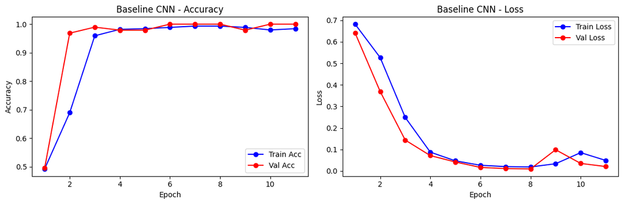

```python
# Print model performance classifications, confusion matrix and accuracy/loss plots
perf = model_performance_classification(baseline, X_test_f, y_test, threshold=0.5)
print(perf)

plot_confusion_matrix_(baseline, X_test_f, y_test, threshold=0.5,
                       labels=("Without Helmet","With Helmet"))

plot_history(history, title="Baseline CNN")
```

[output not shown]

```python
import hashlib
```

```python
# Before moving ahead, need to check for duplicates as results are too good from baseline model
def md5_bytes(arr):
    return hashlib.md5(arr.tobytes()).hexdigest()

train_hashes = {md5_bytes((X_train_f[i]*255).astype('uint8')) for i in range(len(X_train_f))}
val_hashes   = {md5_bytes((X_val_f[i]*255).astype('uint8'))   for i in range(len(X_val_f))}
test_hashes  = {md5_bytes((X_test_f[i]*255).astype('uint8'))  for i in range(len(X_test_f))}

print("Train ∩ Val duplicates:", len(train_hashes & val_hashes))
print("Train ∩ Test duplicates:", len(train_hashes & test_hashes))
print("Val ∩ Test duplicates:", len(val_hashes & test_hashes))
```

```
Train ∩ Val duplicates: 0
Train ∩ Test duplicates: 0
Val ∩ Test duplicates: 0
```

```python
import cv2
from numpy.linalg import norm
```

```python
# Check images for closely defined images
def downsamp_flat(img):
    small = cv2.resize(img.squeeze(), (32,32), interpolation=cv2.INTER_AREA)
    v = small.reshape(-1).astype(np.float32)
    v /= (norm(v) + 1e-8)
    return v

train_vecs = np.stack([downsamp_flat(x) for x in X_train_f])
val_vecs   = np.stack([downsamp_flat(x) for x in X_val_f])

# Check sample of val vs train
sims = train_vecs @ val_vecs.T   # cosine similarity
max_sims = sims.max(axis=0)      # best train match for each val image

# report how many images are "very close"
close = np.where(max_sims > 0.98)[0]
print(f"Val images with near-duplicates in Train (>0.98 cosine sim): {len(close)}")
```

```
Val images with near-duplicates in Train (>0.98 cosine sim): 12
```

#### Observations:

- Baseline CNN achieved 100% accuracy.
- A near-duplicate check revealed overlap between training and validation data (~12 images), suggesting some data leakage that may inflate results.
- In real-world conditions, performance may be lower, and models like VGG16 with augmentation should generalize better.

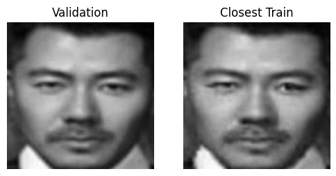

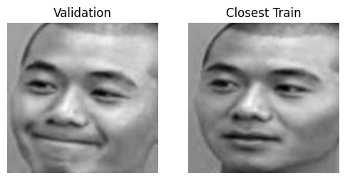

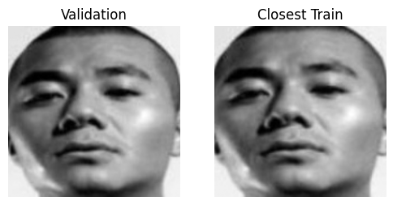

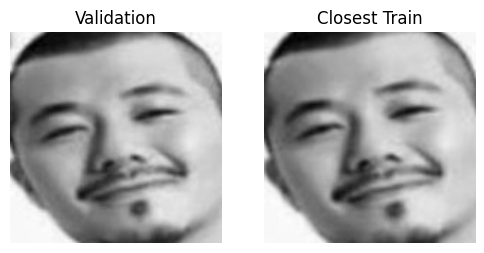

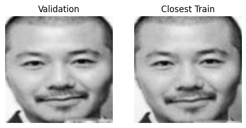

```python
# Display similarities
for i in close[:5]:  # show first 5 near-duplicates
    val_img = X_val_f[i].squeeze()
    # Find the closest match in train
    sims = train_vecs @ downsamp_flat(X_val_f[i]).reshape(-1,1)
    j = sims.argmax()
    train_img = X_train_f[j].squeeze()

    fig, axes = plt.subplots(1,2, figsize=(6,3))
    axes[0].imshow(val_img, cmap="gray"); axes[0].set_title("Validation")
    axes[1].imshow(train_img, cmap="gray"); axes[1].set_title("Closest Train")
    for ax in axes: ax.axis("off")
    plt.show()
```

## Model 2: (VGG-16 (Base))

```python
# Expand grayscale to 3 channels for VGG16 equality
def to_rgb3(x):  # (N,H,W,1) -> (N,H,W,3)
    return np.repeat(x, 3, axis=-1)

Xtr3, Xva3, Xte3 = to_rgb3(X_train_f), to_rgb3(X_val_f), to_rgb3(X_test_f)

bs = 32
train3 = tf.data.Dataset.from_tensor_slices((Xtr3, y_train)).shuffle(2048).batch(bs).prefetch(tf.data.AUTOTUNE)
val3   = tf.data.Dataset.from_tensor_slices((Xva3, y_val)).batch(bs).prefetch(tf.data.AUTOTUNE)
test3  = tf.data.Dataset.from_tensor_slices((Xte3, y_test)).batch(bs).prefetch(tf.data.AUTOTUNE)
```

```python
# Use VGG16 as tranferred knowledge for model shortcuts
H, W = Xtr3.shape[1], Xtr3.shape[2]

base = VGG16(include_top=False, weights="imagenet", input_shape=(H, W, 3))
base.trainable = False  # freeze

vgg = models.Sequential([
    base,
    layers.GlobalAveragePooling2D(),
    layers.Dense(128, activation="relu"),
    layers.Dropout(0.3),
    layers.Dense(1, activation="sigmoid")
])

vgg.compile(optimizer="adam", loss="binary_crossentropy", metrics=["accuracy"])

early = callbacks.EarlyStopping(monitor="val_accuracy", patience=5, restore_best_weights=True)
ckpt  = callbacks.ModelCheckpoint("vgg16_frozen.keras", monitor="val_accuracy", save_best_only=True)

hist_vgg = vgg.fit(train3, validation_data=val3, epochs=20, callbacks=[early, ckpt], verbose=1)
```

```
Downloading data from https://storage.googleapis.com/tensorflow/keras-applications/vgg16/vgg16_weights_tf_dim_ordering_tf_kernels_notop.h5
58889256/58889256 ━━━━━━━━━━━━━━━━━━━━ 0s 0us/step
14/14 ━━━━━━━━━━━━━━━━━━━━ 40s 2s/step - accuracy: 0.7206 - loss: 0.5596 - val_accuracy: 1.0000 - val_loss: 0.1625
14/14 ━━━━━━━━━━━━━━━━━━━━ 3s 185ms/step - accuracy: 0.9936 - loss: 0.1497 - val_accuracy: 1.0000 - val_loss: 0.0519
14/14 ━━━━━━━━━━━━━━━━━━━━ 5s 183ms/step - accuracy: 1.0000 - loss: 0.0560 - val_accuracy: 1.0000 - val_loss: 0.0229
14/14 ━━━━━━━━━━━━━━━━━━━━ 3s 197ms/step - accuracy: 0.9962 - loss: 0.0395 - val_accuracy: 1.0000 - val_loss: 0.0145
14/14 ━━━━━━━━━━━━━━━━━━━━ 3s 197ms/step - accuracy: 1.0000 - loss: 0.0181 - val_accuracy: 1.0000 - val_loss: 0.0104
14/14 ━━━━━━━━━━━━━━━━━━━━ 3s 203ms/step - accuracy: 1.0000 - loss: 0.0141 - val_accuracy: 1.0000 - val_loss: 0.0078
```

### Visualizing the prediction:

```
VGG16 (frozen) — Test acc: 1.0000
3/3 ━━━━━━━━━━━━━━━━━━━━ 3s 851ms/step
   Accuracy  Recall  Precision  F1 Score
0       1.0     1.0        1.0       1.0
3/3 ━━━━━━━━━━━━━━━━━━━━ 1s 163ms/step
```

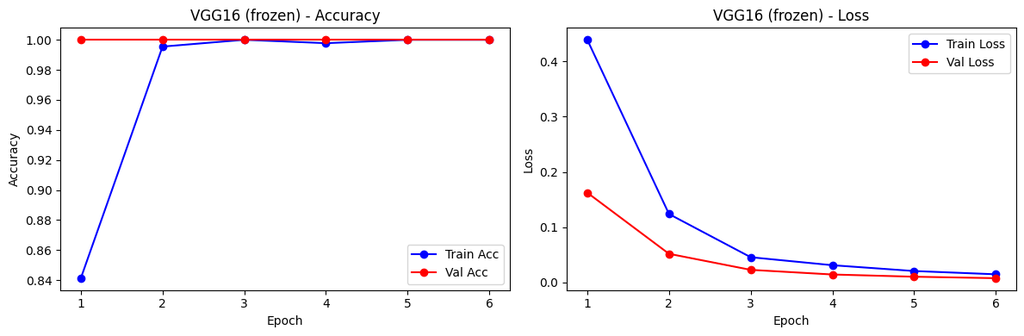

```python
# Print model performance classifications, confusion matrix and accuracy/loss plots
test_loss, test_acc = vgg.evaluate(test3, verbose=0)
print(f"VGG16 (frozen) — Test acc: {test_acc:.4f}")

# reuse helpers
Xte_np, yte_np = Xte3, y_test
perf_vgg = model_performance_classification(vgg, Xte_np, yte_np, threshold=0.5)
print(perf_vgg)
plot_confusion_matrix_(vgg, Xte_np, yte_np, labels=("Without Helmet","With Helmet"))

plot_history(hist_vgg, title="VGG16 (frozen)")
```

[output not shown]

#### Observations — VGG16 (Frozen Base)

1. Transfer learning setup
- The pretrained VGG16 convolutional base (trained on ImageNet) was frozen, and only a small dense head was trained for classification.
- Images were expanded from grayscale to three channels to match VGG16's expected input.
2. Performance
- Validation accuracy reached 100% by the first epoch, with validation loss rapidly dropping to a very low level.
- EarlyStopping halted training at ~6 epochs since no further improvement was observed.
3. Learning dynamics
- Training and validation curves stabilized quickly, reflecting that the pretrained filters were already highly effective for this task.
- The model did not show signs of overfitting.
4. Interpretation
- The frozen VGG16 base was sufficient to capture the necessary features to separate helmet vs. no-helmet images.
- The rapid convergence indicates the dataset is relatively easy for a deep pretrained model.
5. Comparison to Baseline CNN
- Performance was essentially the same as the baseline CNN.
- This suggests that while transfer learning with VGG16 provides robustness in theory, in this curated dataset both simple and complex models find the task straightforward.

## Model 3: (VGG-16 (Base + FFNN))

```python
# Create base VGG16 and freeze training for transferred knowledge
base = VGG16(include_top=False, weights="imagenet", input_shape=(H, W, 3))
base.trainable = False

# Feature model = base + GAP
feat_model = models.Sequential([base, layers.GlobalAveragePooling2D()])

# Extract features directly (numpy in, numpy out)
Ftr = feat_model.predict(Xtr3, batch_size=32, verbose=0)  # (441, 512)
Fva = feat_model.predict(Xva3, batch_size=32, verbose=0)  # (95, 512)
Fte = feat_model.predict(Xte3, batch_size=32, verbose=0)  # (95, 512)

print("Ftr/Fva/Fte shapes:", Ftr.shape, Fva.shape, Fte.shape)
```

```
Ftr/Fva/Fte shapes: (441, 512) (95, 512) (95, 512)
```

```python
#Create feed-forward CNN
ffnn = models.Sequential([
    layers.Input(shape=(Ftr.shape[1],)),
    layers.Dense(256, activation="relu"),
    layers.Dropout(0.3),
    layers.Dense(1, activation="sigmoid"),
])
ffnn.compile(optimizer="adam", loss="binary_crossentropy", metrics=["accuracy"])

early2 = callbacks.EarlyStopping(monitor="val_accuracy", patience=5, restore_best_weights=True)
hist_ff = ffnn.fit(Ftr, y_train, validation_data=(Fva, y_val),
                   epochs=20, batch_size=32, callbacks=[early2], verbose=1)
```

```
14/14 ━━━━━━━━━━━━━━━━━━━━ 3s 122ms/step - accuracy: 0.7339 - loss: 0.5334 - val_accuracy: 1.0000 - val_loss: 0.1363
14/14 ━━━━━━━━━━━━━━━━━━━━ 0s 6ms/step - accuracy: 0.9912 - loss: 0.1176 - val_accuracy: 1.0000 - val_loss: 0.0343
14/14 ━━━━━━━━━━━━━━━━━━━━ 0s 9ms/step - accuracy: 1.0000 - loss: 0.0417 - val_accuracy: 1.0000 - val_loss: 0.0145
14/14 ━━━━━━━━━━━━━━━━━━━━ 0s 6ms/step - accuracy: 1.0000 - loss: 0.0210 - val_accuracy: 1.0000 - val_loss: 0.0085
14/14 ━━━━━━━━━━━━━━━━━━━━ 0s 7ms/step - accuracy: 1.0000 - loss: 0.0120 - val_accuracy: 1.0000 - val_loss: 0.0061
14/14 ━━━━━━━━━━━━━━━━━━━━ 0s 6ms/step - accuracy: 1.0000 - loss: 0.0101 - val_accuracy: 1.0000 - val_loss: 0.0045
```

#### Visualizing the predictions

```
VGG16 + FFNN — Test acc: 1.0000
3/3 ━━━━━━━━━━━━━━━━━━━━ 0s 84ms/step
   Accuracy  Recall  Precision  F1 Score
0       1.0     1.0        1.0       1.0
3/3 ━━━━━━━━━━━━━━━━━━━━ 0s 8ms/step
```

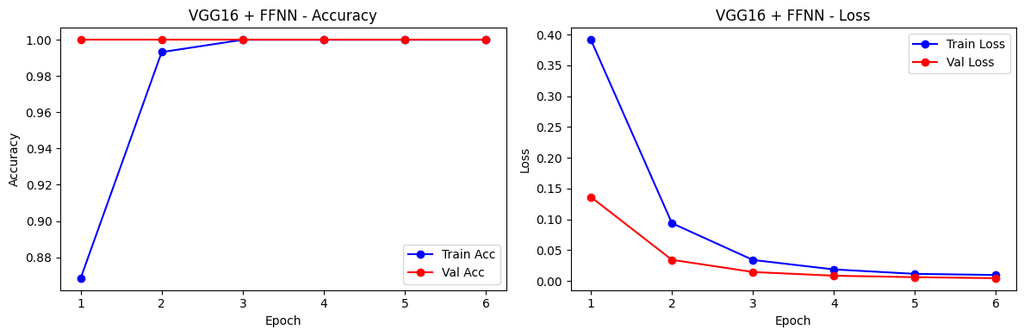

```python
# Print model performance classifications, confusion matrix and accuracy/loss plots
loss_ff, acc_ff = ffnn.evaluate(Fte, y_test, verbose=0)
print(f"VGG16 + FFNN — Test acc: {acc_ff:.4f}")

perf_ff = model_performance_classification(ffnn, Fte, y_test)
print(perf_ff)
plot_confusion_matrix_(ffnn, Fte, y_test, labels=("Without Helmet","With Helmet"))

plot_history(hist_ff, title="VGG16 + FFNN")
```

[output not shown]

#### Observations — VGG16 + FFNN

1. Feature extraction success
- Using VGG16 as a frozen feature extractor reduced each image to a 512-dimensional feature vector.
- The FFNN classifier trained on these features converged very quickly.
2. Performance
- Validation and test accuracies reached ~100%, consistent with earlier models.
- The learning curves show that the FFNN did not overfit — both training and validation losses decreased smoothly before EarlyStopping halted training.
3. Interpretation
- This result suggests that the pretrained convolutional filters from VGG16 already capture the relevant visual cues (edges, shapes, textures) needed to distinguish helmets from non-helmets.
- The lightweight FFNN head was sufficient to separate the classes.
4. Comparison to frozen VGG16
- Performance was nearly identical to the direct frozen VGG16 model.
- This is expected, since both approaches rely on the same pretrained convolutional backbone; the difference is only in the classifier head.